# Project 1 - Stroop Test & Stats

Kyle Shannon - 27 SEP 2015 Project 1.0 - Udacity Data Analyst Nanodegree

```python
import pandas as pd
import numpy as np
import scipy
from scipy import stats, integrate
import matplotlib.pyplot as plt

import seaborn as sns
sns.set(color_codes=True)
%matplotlib inline
```

### 1. What is our independent variable? What is our dependent variable?

Our independant vairable are the congruent vs. incongruent words. For example:

- congruent: RED
- incongruent: BLUE

Our dependant variable is the subject's measured reaction time between congruent and incongruent words.

### 2. What is an appropriate set of hypotheses for this task? What kind of statistical test do you expect to perform? Justify your choices.

Subjects will have longer reaction times when accurately reading through a list of incongruent words versus accurately reading through a list of congruent words. Formally:

- H<sub>0</sub>: μ<sub>congruent</sub> = μ<sub>incongruent</sub>
- H<sub>a</sub>: μ<sub>congruent</sub> < μ<sub>incongruent</sub>

The null hypothesis states that population mean reaction times for the Stroop Effect's Congruent and Incongruent tasks are approximatley equal. The alternative hypothesis states that mean population reactions times for the Congruent task is smaller than for the Incongruent task.

### 3. Report some descriptive statistics regarding this dataset. Include at least one measure of central tendency and at least one measure of variability.

```python
# Summary Statistics for Sample Data
data.describe()
```

|  | Congruent | Incongruent |
| --- | --- | --- |
| count | 24.000000 | 24.000000 |
| mean | 14.051125 | 22.015917 |
| std | 3.559358 | 4.797057 |
| min | 8.630000 | 15.687000 |
| 25% | 11.895250 | 18.716750 |
| 50% | 14.356500 | 21.017500 |
| 75% | 16.200750 | 24.051500 |
| max | 22.328000 | 35.255000 |

```python
# Standard Error of Mean
stats.sem(data, axis=None, ddof=0)
```

```
0.82860977843705996
```

```python
# Mode for Sample Data
data_rounded.mode()
```

|  | Congruent | Incongruent |
| --- | --- | --- |
| 0 | 12 | 21 |
| 1 | 15 | NaN |

```python
# Range for Sample Data
data.apply(max) - data.apply(min)
```

```
Congruent      13.698
Incongruent    19.568
dtype: float64
```

The Incongruent sample mean is definitely higher. Rounding to whole numbers shows the mode to be 12 and 15 for the Congruent and 21 for Incongruent.

The spread of Congruent is less than Incongruent, as can be seen in the difference of sample standard deviations. Furthermore, the Incongruent min, max, and quartiles are all bigger than their respective Congruent counterparts. From the look of the data, there it seems our hypothesis was reasonable.

### 4. Provide one or two visualizations that show the distribution of the sample data. Write one or two sentences noting what you observe about the plot or plots.

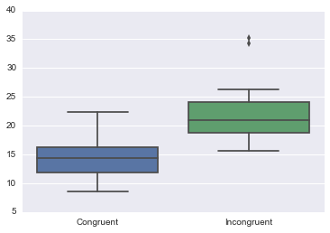

```python
# Boxplot
sns.boxplot(data = data)
```

This box plot visualizes the summary statistics from before, comparing both sample sets. In the Incongruent box plot we see two subjects performed very poorly on the test, this will probably been seen clearly in the distribution plots below.

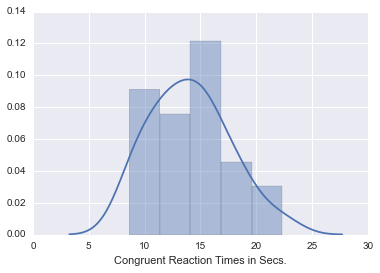

```python
# Distribution Plot
sns.distplot(con_series, axlabel='Congruent Reaction Times in Secs.')
```

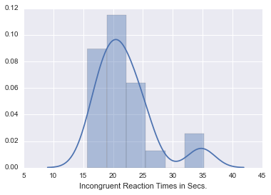

```python
# Distribution Plot
sns.distplot(incon_series, axlabel='Incongruent Reaction Times in Secs.')
```

Distribution plots take a histogram of the data and apply a distribution curve, with area under the curve = 1, while also converting all data counts to become a ratio of one. These graphs provide a good picture into the shape and spread of the data. The samples seem to be relatively normally distributed, except for a slight bump on the right side of the Incongruent plot. Echoing to what was stated earlier in the box plot figure.

### 5. Now, perform the statistical test and report your results. What is your confidence level and your critical statistic value? Do you reject the null hypothesis or fail to reject it? Come to a conclusion in terms of the experiment task. Did the results match up with your expectations?

- degrees of freedom: 23
- confidence level: 95%
- alpha level: .05
- t-critical value: -1.714

```python
stroop_test = stats.ttest_rel(data['Congruent'], data['Incongruent'])
print "The t-statistic is %.3f and the p-value is %.3f." % stroop_test
```

```
The t-statistic is -8.021 and the p-value is 0.000.
```

The p-value is so low that there is almost zero probability we are wrong if we reject the null hypothesis in favor for the alternative. It appears subjects undergoing the stroop test have a decline in mean reaction speeds between completing Congruent and Incongruent tasks. These results fall in line with our original hypothesis that Incongruent reaction speeds will be lower than Congruent due to an increase in some type of neural processing power.

```python
z_stat, p_val = stats.ranksums(data['Congruent'], data['Incongruent'])
print "MWW RankSum P at alpha 0.05 for Congruent and Incongruent =", np.around(p_val, decimals=6)
```

```
MWW RankSum P at alpha 0.05 for Congruent and Incongruent = 0.0
```

We could also use a MWW RankSum test to determine if the sample distributions are significantly different. However, the sns.distplots show data that is fairly normally distributed and we can assume that reaction times are probably normally distributed in the population, much like weight and height. Therefore a simple t-test should suffice.

### 6. Optional: What do you think is responsible for the effects observed? Can you think of an alternative or similar task that would result in a similar effect? Some research about the problem will be helpful for thinking about these two questions!

Any reaction time test could work to mirror these results. Basically, you want a subject to perform the task, but make one more complex than the other. The more complex task should require an increase in neural processing.

A simple example would be to have subjects undergo two tasks. In both they would catch rulers dropped by researchers. The ruler itself acts a measurement of reaction time.

- The first task has subjects visually see the ruler being dropped.
- The second task subjects are blindfolded and given a tactile stimulus. The tactile stimulus would let the subject know the ruler had been dropped.

In this example we would expect subjects to take more time, several milliseconds, to catch the ruler visually. This is because the visual system is much more complicated. The motor system is responsible for telling the hand to catch the ruler. This is the same in both tasks. However, for the body to process that the ruler has been dropped, will take the visual system much more time than the tactile system.

### References:

- http://www.ncbi.nlm.nih.gov/pubmed/11931927
- http://www.ncbi.nlm.nih.gov/pmc/articles/PMC53241/
- https://s3.amazonaws.com/udacity-hosted-downloads/t-table.jpg

## Code and work to derive results:

```python
data = pd.read_csv('stroopdata.csv')
data
```

|  | Congruent | Incongruent |
| --- | --- | --- |
| 0 | 12.079 | 19.278 |
| 1 | 16.791 | 18.741 |
| 2 | 9.564 | 21.214 |
| 3 | 8.630 | 15.687 |
| 4 | 14.669 | 22.803 |
| 5 | 12.238 | 20.878 |
| 6 | 14.692 | 24.572 |
| 7 | 8.987 | 17.394 |
| 8 | 9.401 | 20.762 |
| 9 | 14.480 | 26.282 |
| 10 | 22.328 | 24.524 |
| 11 | 15.298 | 18.644 |
| 12 | 15.073 | 17.510 |
| 13 | 16.929 | 20.330 |
| 14 | 18.200 | 35.255 |
| 15 | 12.130 | 22.158 |
| 16 | 18.495 | 25.139 |
| 17 | 10.639 | 20.429 |
| 18 | 11.344 | 17.425 |
| 19 | 12.369 | 34.288 |
| 20 | 12.944 | 23.894 |
| 21 | 14.233 | 17.960 |
| 22 | 19.710 | 22.058 |
| 23 | 16.004 | 21.157 |

```python
data.describe()
```

|  | Congruent | Incongruent |
| --- | --- | --- |
| count | 24.000000 | 24.000000 |
| mean | 14.051125 | 22.015917 |
| std | 3.559358 | 4.797057 |
| min | 8.630000 | 15.687000 |
| 25% | 11.895250 | 18.716750 |
| 50% | 14.356500 | 21.017500 |
| 75% | 16.200750 | 24.051500 |
| max | 22.328000 | 35.255000 |

```python
data_rounded = np.round(data)
data_rounded
```

|  | Congruent | Incongruent |
| --- | --- | --- |
| 0 | 12 | 19 |
| 1 | 17 | 19 |
| 2 | 10 | 21 |
| 3 | 9 | 16 |
| 4 | 15 | 23 |
| 5 | 12 | 21 |
| 6 | 15 | 25 |
| 7 | 9 | 17 |
| 8 | 9 | 21 |
| 9 | 14 | 26 |
| 10 | 22 | 25 |
| 11 | 15 | 19 |
| 12 | 15 | 18 |
| 13 | 17 | 20 |
| 14 | 18 | 35 |
| 15 | 12 | 22 |
| 16 | 18 | 25 |
| 17 | 11 | 20 |
| 18 | 11 | 17 |
| 19 | 12 | 34 |
| 20 | 13 | 24 |
| 21 | 14 | 18 |
| 22 | 20 | 22 |
| 23 | 16 | 21 |

```python
data.apply(max) - data.apply(min)
```

```
Congruent      13.698
Incongruent    19.568
dtype: float64
```

```python
data_rounded.mode(axis=0, numeric_only = True )
```

|  | Congruent | Incongruent |
| --- | --- | --- |
| 0 | 12 | 21 |
| 1 | 15 | NaN |

```python
con_series = data.ix[:,0]
con_series
```

```
0     12.079
1     16.791
2      9.564
3      8.630
4     14.669
5     12.238
6     14.692
7      8.987
8      9.401
9     14.480
10    22.328
11    15.298
12    15.073
13    16.929
14    18.200
15    12.130
16    18.495
17    10.639
18    11.344
19    12.369
20    12.944
21    14.233
22    19.710
23    16.004
Name: Congruent, dtype: float64
```

```python
incon_series = data.ix[:,1]
incon_series
```

```
0     19.278
1     18.741
2     21.214
3     15.687
4     22.803
5     20.878
6     24.572
7     17.394
8     20.762
9     26.282
10    24.524
11    18.644
12    17.510
13    20.330
14    35.255
15    22.158
16    25.139
17    20.429
18    17.425
19    34.288
20    23.894
21    17.960
22    22.058
23    21.157
Name: Incongruent, dtype: float64
```